# final

Analysis of Purchases and Profits at a Superstore

Brian Wang

Introduction:

This analysis utilizes the Superstore Dataset from Kaggle, which can be accessed from this link: https://www.kaggle.com/datasets/vivek468/superstore-dataset-final. It can also be downloaded directly from this link: https://www.kaggle.com/datasets/vivek468/superstore-dataset-final/download. The objective of this analysis is to uncover trends in profits and losses, discover areas of high sales and high profits, and determine the most and least profitable items.

In this tutorial, I use the following libraries to help process the data:  
pandas  
numpy  
datetime  
re  
scipy

I also use the following libraries to help visualize the data:  
seaborn  
matplotlib  
follium  
pgeocode

And finally, I use these libraries to get supporting data:  
BeautifulSoup  
requests

This code snippet installs pgeocode, which is a library that helps convert postal codes to geographic coordinates.

```python
debug = False # prints debug output if True
```

```python
import sys
!{sys.executable} -m pip install pgeocode # install pgeocode using pip, since this environment doesn't have it by default
```

```python
import pandas as pd
import numpy as np
import folium
import seaborn as sns
import matplotlib as plt
from matplotlib import pyplot
from datetime import datetime
import pgeocode
import requests
from bs4 import BeautifulSoup
import re
import scipy
```

In the code block above, I imported all the libraries that I will need. In the code block below, I read the csv file into a pandas dataframe.

**Data collection and Parsing:**  
We start by downloading the data in the form of a CSV (Comma separated value) file. Other formats work too, but they require different code to read into python. We place this file in the same directory as our code.

```python
data = pd.read_csv('superstore.csv', sep = ',', encoding='windows-1252')
data.head()
```

|  | Row ID | Order ID | Order Date | Ship Date | Ship Mode | Customer ID | Customer Name | Segment | Country | City | ... | Postal Code | Region | Product ID | Category | Sub-Category | Product Name | Sales | Quantity | Discount | Profit |
| --- | --- | --- | --- | --- | --- | --- | --- | --- | --- | --- | --- | --- | --- | --- | --- | --- | --- | --- | --- | --- | --- |
| 0 | 1 | CA-2016-152156 | 11/8/2016 | 11/11/2016 | Second Class | CG-12520 | Claire Gute | Consumer | United States | Henderson | ... | 42420 | South | FUR-BO-10001798 | Furniture | Bookcases | Bush Somerset Collection Bookcase | 261.9600 | 2 | 0.00 | 41.9136 |
| 1 | 2 | CA-2016-152156 | 11/8/2016 | 11/11/2016 | Second Class | CG-12520 | Claire Gute | Consumer | United States | Henderson | ... | 42420 | South | FUR-CH-10000454 | Furniture | Chairs | Hon Deluxe Fabric Upholstered Stacking Chairs,... | 731.9400 | 3 | 0.00 | 219.5820 |
| 2 | 3 | CA-2016-138688 | 6/12/2016 | 6/16/2016 | Second Class | DV-13045 | Darrin Van Huff | Corporate | United States | Los Angeles | ... | 90036 | West | OFF-LA-10000240 | Office Supplies | Labels | Self-Adhesive Address Labels for Typewriters b... | 14.6200 | 2 | 0.00 | 6.8714 |
| 3 | 4 | US-2015-108966 | 10/11/2015 | 10/18/2015 | Standard Class | SO-20335 | Sean O'Donnell | Consumer | United States | Fort Lauderdale | ... | 33311 | South | FUR-TA-10000577 | Furniture | Tables | Bretford CR4500 Series Slim Rectangular Table | 957.5775 | 5 | 0.45 | -383.0310 |
| 4 | 5 | US-2015-108966 | 10/11/2015 | 10/18/2015 | Standard Class | SO-20335 | Sean O'Donnell | Consumer | United States | Fort Lauderdale | ... | 33311 | South | OFF-ST-10000760 | Office Supplies | Storage | Eldon Fold 'N Roll Cart System | 22.3680 | 2 | 0.20 | 2.5164 |

5 rows × 21 columns

**Data management + Representation:**  
The next time is to process the data. This means handling missing values and converting some datatypes into more useful ones. Here, I will be simply ignoring any row with a NA value, since there isn't really a good default value for any of the columns. In this case, there aren't any missing values. I will also convert the order and ship dates to datetime objects, so they can be sorted if we want to perform an analysis based on that.

```python
data.dropna(inplace = True)
```

```python
def to_datetime(row, target_col):
    dt = datetime.strptime(row[target_col], '%m/%d/%Y') # expected format
    return dt
data['Order Datetime'] = data.apply(lambda row: to_datetime(row, 'Order Date'), axis=1)
data['Ship Datetime'] = data.apply(lambda row: to_datetime(row, 'Ship Date'), axis=1)
data.drop(['Order Date', 'Ship Date'], axis = 1, inplace = True)
data.head()
```

|  | Row ID | Order ID | Ship Mode | Customer ID | Customer Name | Segment | Country | City | State | Postal Code | ... | Product ID | Category | Sub-Category | Product Name | Sales | Quantity | Discount | Profit | Order Datetime | Ship Datetime |
| --- | --- | --- | --- | --- | --- | --- | --- | --- | --- | --- | --- | --- | --- | --- | --- | --- | --- | --- | --- | --- | --- |
| 0 | 1 | CA-2016-152156 | Second Class | CG-12520 | Claire Gute | Consumer | United States | Henderson | Kentucky | 42420 | ... | FUR-BO-10001798 | Furniture | Bookcases | Bush Somerset Collection Bookcase | 261.9600 | 2 | 0.00 | 41.9136 | 2016-11-08 | 2016-11-11 |
| 1 | 2 | CA-2016-152156 | Second Class | CG-12520 | Claire Gute | Consumer | United States | Henderson | Kentucky | 42420 | ... | FUR-CH-10000454 | Furniture | Chairs | Hon Deluxe Fabric Upholstered Stacking Chairs,... | 731.9400 | 3 | 0.00 | 219.5820 | 2016-11-08 | 2016-11-11 |
| 2 | 3 | CA-2016-138688 | Second Class | DV-13045 | Darrin Van Huff | Corporate | United States | Los Angeles | California | 90036 | ... | OFF-LA-10000240 | Office Supplies | Labels | Self-Adhesive Address Labels for Typewriters b... | 14.6200 | 2 | 0.00 | 6.8714 | 2016-06-12 | 2016-06-16 |
| 3 | 4 | US-2015-108966 | Standard Class | SO-20335 | Sean O'Donnell | Consumer | United States | Fort Lauderdale | Florida | 33311 | ... | FUR-TA-10000577 | Furniture | Tables | Bretford CR4500 Series Slim Rectangular Table | 957.5775 | 5 | 0.45 | -383.0310 | 2015-10-11 | 2015-10-18 |
| 4 | 5 | US-2015-108966 | Standard Class | SO-20335 | Sean O'Donnell | Consumer | United States | Fort Lauderdale | Florida | 33311 | ... | OFF-ST-10000760 | Office Supplies | Storage | Eldon Fold 'N Roll Cart System | 22.3680 | 2 | 0.20 | 2.5164 | 2015-10-11 | 2015-10-18 |

5 rows × 21 columns

After creating the datetime objects, we can remove the original strings, since they are no longer needed. I also think it may be good to have the items base price, discounted price, and profit per item sold, so I'll make columns for that and calculate based on sales, quantity, and discount.

```python
def get_base_price(row):
    return row['Sales'] / (1 - row['Discount']) / row['Quantity'] # if there were ever 100% discounts, we would have a problem here, but there aren't

def get_sale_price(row):
    return row['Sales'] / row['Quantity']

def get_per_item_profit(row):
    return row['Profit'] / row['Quantity']

data['Base Price'] = data.apply(lambda row: get_base_price(row), axis=1)
data['Sale Price'] = data.apply(lambda row: get_sale_price(row), axis=1)
data['Profit Per Item'] = data.apply(lambda row: get_per_item_profit(row), axis=1)

data.sort_values(by = 'Profit Per Item', inplace = True, ascending = False) # we sort for the highest profit per item

data
```

|  | Row ID | Order ID | Ship Mode | Customer ID | Customer Name | Segment | Country | City | State | Postal Code | ... | Product Name | Sales | Quantity | Discount | Profit | Order Datetime | Ship Datetime | Base Price | Sale Price | Profit Per Item |
| --- | --- | --- | --- | --- | --- | --- | --- | --- | --- | --- | --- | --- | --- | --- | --- | --- | --- | --- | --- | --- | --- |
| 6826 | 6827 | CA-2016-118689 | Standard Class | TC-20980 | Tamara Chand | Corporate | United States | Lafayette | Indiana | 47905 | ... | Canon imageCLASS 2200 Advanced Copier | 17499.950 | 5 | 0.0 | 8399.9760 | 2016-10-02 | 2016-10-09 | 3499.99 | 3499.990 | 1679.9952 |
| 4190 | 4191 | CA-2017-166709 | Standard Class | HL-15040 | Hunter Lopez | Consumer | United States | Newark | Delaware | 19711 | ... | Canon imageCLASS 2200 Advanced Copier | 10499.970 | 3 | 0.0 | 5039.9856 | 2017-11-17 | 2017-11-22 | 3499.99 | 3499.990 | 1679.9952 |
| 8153 | 8154 | CA-2017-140151 | First Class | RB-19360 | Raymond Buch | Consumer | United States | Seattle | Washington | 98115 | ... | Canon imageCLASS 2200 Advanced Copier | 13999.960 | 4 | 0.0 | 6719.9808 | 2017-03-23 | 2017-03-25 | 3499.99 | 3499.990 | 1679.9952 |
| 318 | 319 | CA-2014-164973 | Standard Class | NM-18445 | Nathan Mautz | Home Office | United States | New York City | New York | 10024 | ... | Canon imageCLASS MF7460 Monochrome Digital Las... | 3991.980 | 2 | 0.0 | 1995.9900 | 2014-11-04 | 2014-11-09 | 1995.99 | 1995.990 | 997.9950 |
| 2623 | 2624 | CA-2017-127180 | First Class | TA-21385 | Tom Ashbrook | Home Office | United States | New York City | New York | 10024 | ... | Canon imageCLASS 2200 Advanced Copier | 11199.968 | 4 | 0.2 | 3919.9888 | 2017-10-22 | 2017-10-24 | 3499.99 | 2799.992 | 979.9972 |
| ... | ... | ... | ... | ... | ... | ... | ... | ... | ... | ... | ... | ... | ... | ... | ... | ... | ... | ... | ... | ... | ... |
| 4991 | 4992 | US-2017-122714 | Standard Class | HG-14965 | Henry Goldwyn | Corporate | United States | Chicago | Illinois | 60653 | ... | Ibico EPK-21 Electric Binding System | 1889.990 | 5 | 0.8 | -2929.4845 | 2017-12-07 | 2017-12-13 | 1889.99 | 377.998 | -585.8969 |
| 3011 | 3012 | CA-2017-134845 | Standard Class | SR-20425 | Sharelle Roach | Home Office | United States | Louisville | Colorado | 80027 | ... | Lexmark MX611dhe Monochrome Laser Printer | 2549.985 | 5 | 0.7 | -3399.9800 | 2017-04-17 | 2017-04-23 | 1699.99 | 509.997 | -679.9960 |
| 683 | 684 | US-2017-168116 | Same Day | GT-14635 | Grant Thornton | Corporate | United States | Burlington | North Carolina | 27217 | ... | Cubify CubeX 3D Printer Triple Head Print | 7999.980 | 4 | 0.5 | -3839.9904 | 2017-11-04 | 2017-11-04 | 3999.99 | 1999.995 | -959.9976 |
| 7772 | 7773 | CA-2016-108196 | Standard Class | CS-12505 | Cindy Stewart | Consumer | United States | Lancaster | Ohio | 43130 | ... | Cubify CubeX 3D Printer Double Head Print | 4499.985 | 5 | 0.7 | -6599.9780 | 2016-11-25 | 2016-12-02 | 2999.99 | 899.997 | -1319.9956 |
| 3151 | 3152 | CA-2015-147830 | First Class | NF-18385 | Natalie Fritzler | Consumer | United States | Newark | Ohio | 43055 | ... | Cubify CubeX 3D Printer Double Head Print | 1799.994 | 2 | 0.7 | -2639.9912 | 2015-12-15 | 2015-12-18 | 2999.99 | 899.997 | -1319.9956 |

9994 rows × 24 columns

**Exploratory Data Analysis:**  
We can now explore the data to find insights. I will start by finding all instances of negative profit, and look for commonalities in the entries.

```python
neg_profit = data[data['Profit'] < 0] # select entries where profit is negative
neg_profit = neg_profit.sort_values(by = 'Profit', ascending = True) # display the biggest losses first
neg_profit
```

|  | Row ID | Order ID | Ship Mode | Customer ID | Customer Name | Segment | Country | City | State | Postal Code | ... | Product Name | Sales | Quantity | Discount | Profit | Order Datetime | Ship Datetime | Base Price | Sale Price | Profit Per Item |
| --- | --- | --- | --- | --- | --- | --- | --- | --- | --- | --- | --- | --- | --- | --- | --- | --- | --- | --- | --- | --- | --- |
| 7772 | 7773 | CA-2016-108196 | Standard Class | CS-12505 | Cindy Stewart | Consumer | United States | Lancaster | Ohio | 43130 | ... | Cubify CubeX 3D Printer Double Head Print | 4499.985 | 5 | 0.7 | -6599.9780 | 2016-11-25 | 2016-12-02 | 2999.99 | 899.997 | -1319.9956 |
| 683 | 684 | US-2017-168116 | Same Day | GT-14635 | Grant Thornton | Corporate | United States | Burlington | North Carolina | 27217 | ... | Cubify CubeX 3D Printer Triple Head Print | 7999.980 | 4 | 0.5 | -3839.9904 | 2017-11-04 | 2017-11-04 | 3999.99 | 1999.995 | -959.9976 |
| 9774 | 9775 | CA-2014-169019 | Standard Class | LF-17185 | Luke Foster | Consumer | United States | San Antonio | Texas | 78207 | ... | GBC DocuBind P400 Electric Binding System | 2177.584 | 8 | 0.8 | -3701.8928 | 2014-07-26 | 2014-07-30 | 1360.99 | 272.198 | -462.7366 |
| 3011 | 3012 | CA-2017-134845 | Standard Class | SR-20425 | Sharelle Roach | Home Office | United States | Louisville | Colorado | 80027 | ... | Lexmark MX611dhe Monochrome Laser Printer | 2549.985 | 5 | 0.7 | -3399.9800 | 2017-04-17 | 2017-04-23 | 1699.99 | 509.997 | -679.9960 |
| 4991 | 4992 | US-2017-122714 | Standard Class | HG-14965 | Henry Goldwyn | Corporate | United States | Chicago | Illinois | 60653 | ... | Ibico EPK-21 Electric Binding System | 1889.990 | 5 | 0.8 | -2929.4845 | 2017-12-07 | 2017-12-13 | 1889.99 | 377.998 | -585.8969 |
| ... | ... | ... | ... | ... | ... | ... | ... | ... | ... | ... | ... | ... | ... | ... | ... | ... | ... | ... | ... | ... | ... |
| 4660 | 4661 | CA-2015-112130 | Standard Class | SV-20785 | Stewart Visinsky | Consumer | United States | Philadelphia | Pennsylvania | 19140 | ... | SanDisk Cruzer 16 GB USB Flash Drive | 27.552 | 3 | 0.2 | -0.3444 | 2015-05-03 | 2015-05-07 | 11.48 | 9.184 | -0.1148 |
| 7413 | 7414 | CA-2017-121125 | Standard Class | MG-17890 | Michael Granlund | Home Office | United States | Tigard | Oregon | 97224 | ... | Tensor Brushed Steel Torchiere Floor Lamp | 13.592 | 1 | 0.2 | -0.3398 | 2017-05-30 | 2017-06-03 | 16.99 | 13.592 | -0.3398 |
| 1566 | 1567 | CA-2015-129112 | First Class | AW-10840 | Anthony Witt | Consumer | United States | Allen | Texas | 75002 | ... | Kingston Digital DataTraveler 16GB USB 2.0 | 21.480 | 3 | 0.2 | -0.2685 | 2015-11-29 | 2015-11-30 | 8.95 | 7.160 | -0.0895 |
| 1496 | 1497 | CA-2017-152485 | Standard Class | JD-15790 | John Dryer | Consumer | United States | Coppell | Texas | 75019 | ... | Acco Perma 3000 Stacking Storage Drawers | 16.784 | 1 | 0.2 | -0.2098 | 2017-09-04 | 2017-09-08 | 20.98 | 16.784 | -0.2098 |
| 3228 | 3229 | CA-2014-108189 | First Class | ES-14080 | Erin Smith | Corporate | United States | Tempe | Arizona | 85281 | ... | Kingston Digital DataTraveler 16GB USB 2.0 | 7.160 | 1 | 0.2 | -0.0895 | 2014-10-02 | 2014-10-05 | 8.95 | 7.160 | -0.0895 |

1871 rows × 24 columns

We can see that many of the biggest losses have multiple items sold, which makes sense. To control for this, we can sort by loss per item.

```python
neg_profit = neg_profit.sort_values(by = 'Profit Per Item', ascending = True) # display the biggest losses first
neg_profit
```

|  | Row ID | Order ID | Ship Mode | Customer ID | Customer Name | Segment | Country | City | State | Postal Code | ... | Product Name | Sales | Quantity | Discount | Profit | Order Datetime | Ship Datetime | Base Price | Sale Price | Profit Per Item |
| --- | --- | --- | --- | --- | --- | --- | --- | --- | --- | --- | --- | --- | --- | --- | --- | --- | --- | --- | --- | --- | --- |
| 7772 | 7773 | CA-2016-108196 | Standard Class | CS-12505 | Cindy Stewart | Consumer | United States | Lancaster | Ohio | 43130 | ... | Cubify CubeX 3D Printer Double Head Print | 4499.985 | 5 | 0.7 | -6599.9780 | 2016-11-25 | 2016-12-02 | 2999.99 | 899.997 | -1319.9956 |
| 3151 | 3152 | CA-2015-147830 | First Class | NF-18385 | Natalie Fritzler | Consumer | United States | Newark | Ohio | 43055 | ... | Cubify CubeX 3D Printer Double Head Print | 1799.994 | 2 | 0.7 | -2639.9912 | 2015-12-15 | 2015-12-18 | 2999.99 | 899.997 | -1319.9956 |
| 683 | 684 | US-2017-168116 | Same Day | GT-14635 | Grant Thornton | Corporate | United States | Burlington | North Carolina | 27217 | ... | Cubify CubeX 3D Printer Triple Head Print | 7999.980 | 4 | 0.5 | -3839.9904 | 2017-11-04 | 2017-11-04 | 3999.99 | 1999.995 | -959.9976 |
| 3011 | 3012 | CA-2017-134845 | Standard Class | SR-20425 | Sharelle Roach | Home Office | United States | Louisville | Colorado | 80027 | ... | Lexmark MX611dhe Monochrome Laser Printer | 2549.985 | 5 | 0.7 | -3399.9800 | 2017-04-17 | 2017-04-23 | 1699.99 | 509.997 | -679.9960 |
| 4991 | 4992 | US-2017-122714 | Standard Class | HG-14965 | Henry Goldwyn | Corporate | United States | Chicago | Illinois | 60653 | ... | Ibico EPK-21 Electric Binding System | 1889.990 | 5 | 0.8 | -2929.4845 | 2017-12-07 | 2017-12-13 | 1889.99 | 377.998 | -585.8969 |
| ... | ... | ... | ... | ... | ... | ... | ... | ... | ... | ... | ... | ... | ... | ... | ... | ... | ... | ... | ... | ... | ... |
| 4660 | 4661 | CA-2015-112130 | Standard Class | SV-20785 | Stewart Visinsky | Consumer | United States | Philadelphia | Pennsylvania | 19140 | ... | SanDisk Cruzer 16 GB USB Flash Drive | 27.552 | 3 | 0.2 | -0.3444 | 2015-05-03 | 2015-05-07 | 11.48 | 9.184 | -0.1148 |
| 1566 | 1567 | CA-2015-129112 | First Class | AW-10840 | Anthony Witt | Consumer | United States | Allen | Texas | 75002 | ... | Kingston Digital DataTraveler 16GB USB 2.0 | 21.480 | 3 | 0.2 | -0.2685 | 2015-11-29 | 2015-11-30 | 8.95 | 7.160 | -0.0895 |
| 8881 | 8882 | CA-2016-135594 | Second Class | AH-10120 | Adrian Hane | Home Office | United States | Aurora | Illinois | 60505 | ... | Kingston Digital DataTraveler 16GB USB 2.0 | 50.120 | 7 | 0.2 | -0.6265 | 2016-06-30 | 2016-07-03 | 8.95 | 7.160 | -0.0895 |
| 2769 | 2770 | US-2015-122140 | Standard Class | MO-17950 | Michael Oakman | Consumer | United States | Dallas | Texas | 75220 | ... | Kingston Digital DataTraveler 16GB USB 2.0 | 50.120 | 7 | 0.2 | -0.6265 | 2015-04-02 | 2015-04-07 | 8.95 | 7.160 | -0.0895 |
| 3228 | 3229 | CA-2014-108189 | First Class | ES-14080 | Erin Smith | Corporate | United States | Tempe | Arizona | 85281 | ... | Kingston Digital DataTraveler 16GB USB 2.0 | 7.160 | 1 | 0.2 | -0.0895 | 2014-10-02 | 2014-10-05 | 8.95 | 7.160 | -0.0895 |

1871 rows × 24 columns

Looking at this, I noticed that the highest and lowest entries all have a non zero discount. I want to check further and see if any non discounted items sold at a loss, so I filter the table again.

```python
neg_profit2 = neg_profit[neg_profit['Discount'] == 0] # filter for discount = 0
neg_profit2
```

|  | Row ID | Order ID | Ship Mode | Customer ID | Customer Name | Segment | Country | City | State | Postal Code | ... | Product Name | Sales | Quantity | Discount | Profit | Order Datetime | Ship Datetime | Base Price | Sale Price | Profit Per Item |
| --- | --- | --- | --- | --- | --- | --- | --- | --- | --- | --- | --- | --- | --- | --- | --- | --- | --- | --- | --- | --- | --- |

0 rows × 24 columns

We found out that the profit is always positive when there is no discount, which makes sense. Next, I want to look at factors that may affect profits. Since profits per item makes the most sense to look at, I will be graphing the variables against profits per item rather than overall profits. We can use matplotlib and seaborn for this, since they make it very easy to graph different variables against each other.

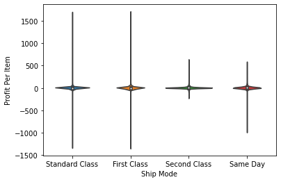

```python
fig, ax = plt.pyplot.subplots()

sns.violinplot(x = 'Ship Mode', y = 'Profit Per Item', data=data, ax = ax)
ax.set_xlabel("Ship Mode")
ax.set_ylabel("Profit Per Item")
```

This graph looks a bit squished due to outliers. From this, we can conclude that the vast majority of items across all classes have very little profit or loss. We can also see that the median for each mode of shipping is around the same, so it doesn't seem that shipping mode affects profits much. To get a closer look at the center, we can remove outliers and see what the graph looks like.

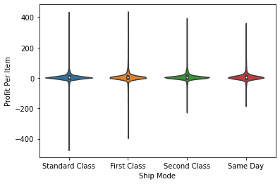

```python
no_outliers = data[data['Profit Per Item'] < 500]
no_outliers = no_outliers[no_outliers['Profit Per Item'] > -500]

fig, ax = plt.pyplot.subplots()

sns.violinplot(x = 'Ship Mode', y = 'Profit Per Item', data=no_outliers, ax = ax)
ax.set_xlabel('Ship Mode')
ax.set_ylabel('Profit Per Item')
```

```
array([[<AxesSubplot:title={'center':'Profit Per Item'}>]], dtype=object)
```

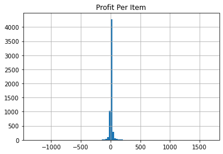

```python
data[data['Ship Mode'] == 'Standard Class'].hist(column = 'Profit Per Item', bins = 100)
```

```
array([[<AxesSubplot:title={'center':'Profit Per Item'}>]], dtype=object)
```

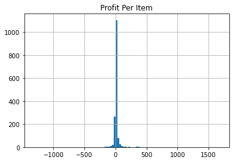

```python
data[data['Ship Mode'] == 'First Class'].hist(column = 'Profit Per Item', bins = 100)
```

```
array([[<AxesSubplot:title={'center':'Profit Per Item'}>]], dtype=object)
```

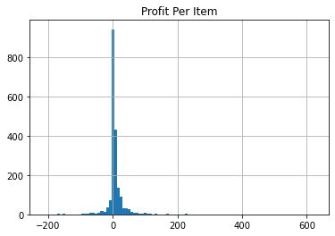

```python
data[data['Ship Mode'] == 'Second Class'].hist(column = 'Profit Per Item', bins = 100)
```

```
array([[<AxesSubplot:title={'center':'Profit Per Item'}>]], dtype=object)
```

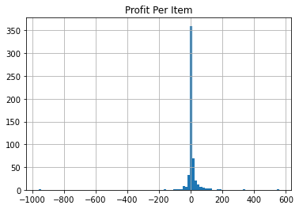

```python
data[data['Ship Mode'] == 'Same Day'].hist(column = 'Profit Per Item', bins = 100)
```

From these graphs, it looks like shipping mode doesn't have much of an impact on profit per item, and the vast majority of profits are slightly above 0, which agrees with the violin plots we made earlier.

It may also be interesting to look at net profits and quantity by some variables. Since we can't average names, and it's inconvenient and unnecessary to average dates, we can drop them and anything else that we don't need.

```python
pruned_data = data.drop(['Row ID', 'Base Price', 'Sale Price', 'Region', 'Product ID', 'Category', 'Sub-Category', 'Order Datetime', 'Ship Datetime', 'Order ID', 'Ship Mode', 'Customer Name', 'Customer ID', 'Segment', 'Country', 'City', 'State', 'Postal Code'], axis = 1)
grouped_data = pruned_data.groupby('Product Name', as_index = False).agg({'Sales':'sum', 'Quantity':'sum','Profit':'sum', 'Discount':'mean', 'Profit Per Item':'mean'}) # we separate the dataframe into groups by product name and sum the results, but take the mean discount
grouped_data['Profit Per Item'] = grouped_data.apply(lambda row: get_per_item_profit(row), axis=1) # update profit per item since adding it together doesnt work
grouped_data['Profit Percent'] = grouped_data.apply(lambda row: row['Profit'] / row['Sales'] * 100, axis=1)
grouped_data.sort_values(by = 'Profit Percent', inplace = True, ascending = False)

grouped_data
```

|  | Product Name | Sales | Quantity | Profit | Discount | Profit Per Item | Profit Percent |
| --- | --- | --- | --- | --- | --- | --- | --- |
| 109 | Adams Telephone Message Book w/Frequently-Call... | 223.440 | 28 | 111.7200 | 0.0 | 3.990000 | 50.000000 |
| 405 | Canon imageCLASS MF7460 Monochrome Digital Las... | 3991.980 | 2 | 1995.9900 | 0.0 | 997.995000 | 50.000000 |
| 181 | Avery 475 | 266.400 | 18 | 133.2000 | 0.0 | 7.400000 | 50.000000 |
| 1673 | Xerox 1890 | 244.700 | 5 | 122.3500 | 0.0 | 24.470000 | 50.000000 |
| 1567 | Tops Green Bar Computer Printout Paper | 342.580 | 7 | 171.2900 | 0.0 | 24.470000 | 50.000000 |
| ... | ... | ... | ... | ... | ... | ... | ... |
| 1838 | Zebra GK420t Direct Thermal/Thermal Transfer P... | 703.710 | 6 | -938.2800 | 0.7 | -156.380000 | -133.333333 |
| 1215 | Okidata B401 Printer | 179.991 | 3 | -251.9874 | 0.7 | -83.995800 | -140.000000 |
| 613 | Euro Pro Shark Stick Mini Vacuum | 170.744 | 11 | -325.6332 | 0.6 | -29.603018 | -190.714286 |
| 388 | Bush Westfield Collection Bookcases, Dark Cher... | 90.882 | 3 | -190.8522 | 0.7 | -63.617400 | -210.000000 |
| 605 | Eureka Disposable Bags for Sanitaire Vibra Gro... | 1.624 | 2 | -4.4660 | 0.8 | -2.233000 | -275.000000 |

1850 rows × 7 columns

Here, we get a bunch of stats by item. It is important to note that the discount is approximate, since we are averaging across transcations instead of quantity of items, but it is a decent approximation. We can immediately see that the highest profit margin is 50%, and most of the items with 50% profit margin are sold at 0 discount.

```python
grouped_data.sort_values(by = 'Quantity', inplace = True, ascending = False)

grouped_data
```

|  | Product Name | Sales | Quantity | Profit | Discount | Profit Per Item | Profit Percent |
| --- | --- | --- | --- | --- | --- | --- | --- |
| 1499 | Staples | 755.470 | 215 | 292.2046 | 0.100000 | 1.359091 | 38.678518 |
| 1493 | Staple envelope | 1686.812 | 170 | 751.6290 | 0.075000 | 4.421347 | 44.559145 |
| 537 | Easy-staple paper | 2504.192 | 150 | 1096.0292 | 0.060870 | 7.306861 | 43.767778 |
| 1500 | Staples in misc. colors | 478.812 | 86 | 124.0516 | 0.063158 | 1.442460 | 25.908206 |
| 942 | KI Adjustable-Height Table | 4552.641 | 74 | -248.4822 | 0.236111 | -3.357868 | -5.457979 |
| ... | ... | ... | ... | ... | ... | ... | ... |
| 385 | Bush Saratoga Collection 5-Shelf Bookcase, Han... | 119.833 | 1 | -12.6882 | 0.150000 | -12.688200 | -10.588235 |
| 749 | Global Enterprise Series Seating Low-Back Swiv... | 207.184 | 1 | 25.8980 | 0.200000 | 25.898000 | 12.500000 |
| 1253 | Penpower WorldCard Pro Card Scanner | 91.475 | 1 | -1.8295 | 0.500000 | -1.829500 | -2.000000 |
| 356 | Boston 1900 Electric Pencil Sharpener | 14.980 | 1 | 4.4940 | 0.000000 | 4.494000 | 30.000000 |
| 1793 | Xerox 20 | 6.480 | 1 | 3.1104 | 0.000000 | 3.110400 | 48.000000 |

1850 rows × 7 columns

Finally, we sort by profit to peep at the most and least profitable items.

```python
grouped_data.sort_values(by = 'Profit', inplace = True, ascending = False)

grouped_data
```

|  | Product Name | Sales | Quantity | Profit | Discount | Profit Per Item | Profit Percent |
| --- | --- | --- | --- | --- | --- | --- | --- |
| 404 | Canon imageCLASS 2200 Advanced Copier | 61599.824 | 20 | 25199.9280 | 0.120000 | 1259.996400 | 40.909091 |
| 650 | Fellowes PB500 Electric Punch Plastic Comb Bin... | 27453.384 | 31 | 7753.0390 | 0.240000 | 250.098032 | 28.240741 |
| 805 | Hewlett Packard LaserJet 3310 Copier | 18839.686 | 38 | 6983.8836 | 0.200000 | 183.786411 | 37.070064 |
| 400 | Canon PC1060 Personal Laser Copier | 11619.834 | 19 | 4570.9347 | 0.150000 | 240.575511 | 39.337349 |
| 787 | HP Designjet T520 Inkjet Large Format Printer ... | 18374.895 | 12 | 4094.9766 | 0.166667 | 341.248050 | 22.285714 |
| ... | ... | ... | ... | ... | ... | ... | ... |
| 376 | Bush Advantage Collection Racetrack Conference... | 9544.725 | 33 | -1934.3976 | 0.350000 | -58.618109 | -20.266667 |
| 425 | Chromcraft Bull-Nose Wood Oval Conference Tabl... | 9917.640 | 27 | -2876.1156 | 0.280000 | -106.522800 | -29.000000 |
| 476 | Cubify CubeX 3D Printer Triple Head Print | 7999.980 | 4 | -3839.9904 | 0.500000 | -959.997600 | -48.000000 |
| 985 | Lexmark MX611dhe Monochrome Laser Printer | 16829.901 | 18 | -4589.9730 | 0.400000 | -254.998500 | -27.272727 |
| 475 | Cubify CubeX 3D Printer Double Head Print | 11099.963 | 9 | -8879.9704 | 0.533333 | -986.663378 | -80.000000 |

1850 rows × 7 columns

Next, I will try to visualize where sales are occuring. I will use pgeocode to convert the zip codes in the data to geographics coordinates, and folium to plot sales. Since the data is only in the United States (which will be shown in the code snippet below), I will zoom the map to the US at the start.

```python
pruned_data = data.drop(['Row ID', 'Base Price', 'Sale Price', 'Product Name', 'Region', 'Product ID', 'Category', 'Sub-Category', 'Order Datetime', 'Ship Datetime', 'Order ID', 'Ship Mode', 'Customer Name', 'Customer ID', 'Segment', 'Country', 'City', 'State'], axis = 1)
grouped_data2 = pruned_data.groupby('Postal Code', as_index = False).agg({'Sales':'sum', 'Quantity':'sum','Profit':'sum', 'Discount':'mean', 'Profit Per Item':'mean'}) # we separate the dataframe into groups by postal code
grouped_data2['Profit Per Item'] = grouped_data2.apply(lambda row: get_per_item_profit(row), axis=1) # update profit per item since adding it together doesnt work
grouped_data2['Profit Percent'] = grouped_data2.apply(lambda row: row['Profit'] / row['Sales'] * 100, axis=1)
grouped_data2.sort_values(by = 'Quantity', inplace = True, ascending = False)

grouped_data2
```

|  | Postal Code | Sales | Quantity | Profit | Discount | Profit Per Item | Profit Percent |
| --- | --- | --- | --- | --- | --- | --- | --- |
| 55 | 10035 | 77357.885 | 953 | 16533.8669 | 0.047529 | 17.349283 | 21.373215 |
| 52 | 10009 | 54761.496 | 848 | 13697.0019 | 0.054585 | 16.152125 | 25.012103 |
| 54 | 10024 | 78697.182 | 840 | 21653.7248 | 0.064783 | 25.778244 | 27.515248 |
| 578 | 94122 | 52667.467 | 802 | 7712.5958 | 0.072660 | 9.616703 | 14.643947 |
| 53 | 10011 | 45551.598 | 776 | 10152.3901 | 0.059585 | 13.082977 | 22.287671 |
| ... | ... | ... | ... | ... | ... | ... | ... |
| 623 | 98208 | 3.856 | 1 | 1.3978 | 0.200000 | 1.397800 | 36.250000 |
| 462 | 80122 | 72.294 | 1 | -98.8018 | 0.700000 | -98.801800 | -136.666667 |
| 63 | 11757 | 55.480 | 1 | 26.6304 | 0.000000 | 26.630400 | 48.000000 |
| 475 | 83501 | 9.584 | 1 | 3.3544 | 0.200000 | 3.354400 | 35.000000 |
| 612 | 98002 | 4.180 | 1 | 1.5048 | 0.000000 | 1.504800 | 36.000000 |

631 rows × 7 columns

```python
print(data['Country'].unique()) # the only country in this datset is the US
```

```
['United States']
```

```python
def sales_circle_size(sales): # two functions to help determine how large the plotted points will be based on the number of sales
    if sales <= 1:
        return 1
    return sales ** 0.5/ 10

def profit_circle_size(profit):
    if profit <= 1:
        return 1
    return profit ** 0.5 / 10
```

```python
map_osm = folium.Map(location=[36.84, -90.3], zoom_start=4)

code_to_loc = {}
nomi = pgeocode.Nominatim('us') # use us postal codes
for code, row in grouped_data2.iterrows():
    loc = nomi.query_postal_code('{:05}'.format(int(row[0])))
    if(np.isnan(loc.latitude)):
        if(debug):
            print(loc)
        continue
    code_to_loc[int(row[0])] = [loc.latitude, loc.longitude]
    if row['Sales'] > 0:
        folium.CircleMarker(location = [loc.latitude, loc.longitude], radius = sales_circle_size(row['Sales']), weight = 0.5, color = "blue", fill = True).add_to(map_osm)
    elif debug:
        print("0 sales?")
    if row['Profit'] > 0:
        folium.CircleMarker(location = [loc.latitude, loc.longitude], radius = profit_circle_size(row['Profit']), weight = 2, color = "green", fill = True).add_to(map_osm)
    else:
        folium.CircleMarker(location = [loc.latitude, loc.longitude], radius = profit_circle_size(-1 * row['Profit']), weight = 1, color = "red", fill = True).add_to(map_osm)

map_osm
```

Make this Notebook Trusted to load map: File -> Trust Notebook

[interactive chart not shown]

In this map, blue circles represent sales, green circles represent profits, and red circles represent losses. All are proportional to the area of the circle. It looks like proximity to major port cities is a big factor on whether or not a store is profitable or not. Stores on the coasts seem to be more profitable than stores in the central US. However, there are many exceptions, so this likely doesn't account for everything. However, there may still be some correlation, so this is what we will examine more closely.

**Hypothesis Testing** </br> First, we have to decide which ports to count. I found a list of the top 10 US ports here: https://www.icontainers.com/us/2017/05/16/top-10-us-ports/, which is what I have decided to use, but the set of ports could be greater or less if you want. You could even just do proximity to water. The latitude and longitude of all the ports in the US can be found here: https://www.gccports.com/ports/latitude-longitude/search. My hypothesis will be that there is a correlation between distance from the top 10 ports and profit per item, and the null hypothesis will be that there is no correlation.

```python
full_port_set = False # toggle for using full set of available US ports
```

```python
def parse_coord(s):
    s = strip_td(s)
    coords = re.split('°|\'', s)
    val = float(coords[0]) + float(coords[1]) / 60.0 # process degrees and minutes
    if coords[2] == 'W' or coords[2] == 'S':
        val = val * -1
    return val

def strip_td(s):
    s = str(s)
    s = s[4:len(s) - 5]
    return s

target_ports = ['Miami', 'Oakland', 'Charleston', 'Georgetown', 'Houston', 'Norfolk', 'Seattle', 'Tacoma', 'Savannah', 'Brunswick', 'Newark', 'Brooklyn', 'Long Beach', 'Los Angeles']
target_coords = []
port_data = {}
for i in range(1, 10): # 9 pages
    # this websites SSL certificate is expired so we have to disable verification if we don't want to do it manually
    res = requests.get('https://www.gccports.com/ports/latitude-longitude/search/?n=&c=231&cd=&per_page=' + str(i), verify = False)
    root = BeautifulSoup(res.content, 'html.parser') # parse html using beautiful soup
    table = root.find('table') # find the table of ports
    ports = table.findAll('td') # find all the rows containing data
    for i in range(0, len(ports))[::5]: # row are 5 elements long, position 0 contains name, 3 and 4 contains latitude
        port_data[strip_td(ports[i])] = [parse_coord(ports[i + 3]), parse_coord(ports[i + 4])]
if debug:
    print(port_data)
for port in (port_data.keys() if full_port_set else target_ports):
    if port in port_data.keys():
        target_coords.append(port_data[port])
    else:
        print('Could not find port ' + port)
if debug:
    print(target_coords)
```

```
Could not find port Oakland
Could not find port Georgetown
Could not find port Brunswick
Could not find port Newark
Could not find port Brooklyn
```

A few of the ports mentioned in the article aren't here, but that is ok! We can now add a column for the minimum distance to a port

```python
def distance(a, b):
    return ((a[0] - b[0]) ** 2 + (a[1] - b[1]) ** 2) ** 0.5

def best_distance(loc):
    best_distance = distance(loc, target_coords[0])
    best_port = target_coords[0]
    for target in target_coords:
        dis = distance(loc, target)
        if dis < best_distance:
            best_distance = dis
            best_port = target
    return best_distance

grouped_data2['Port Distance'] = grouped_data2.apply(lambda row: best_distance(code_to_loc[int(row[0])]), axis=1)
grouped_data2.sort_values(by = 'Port Distance', inplace = True)
grouped_data2
```

|  | Postal Code | Sales | Quantity | Profit | Discount | Profit Per Item | Profit Percent | Port Distance |
| --- | --- | --- | --- | --- | --- | --- | --- | --- |
| 620 | 98105 | 41838.008 | 625 | 8734.6042 | 0.069091 | 13.975367 | 20.877199 | 0.070542 |
| 619 | 98103 | 36541.826 | 539 | 7117.6170 | 0.058278 | 13.205226 | 19.478000 | 0.073883 |
| 166 | 33142 | 3619.421 | 38 | -980.0357 | 0.381818 | -25.790413 | -27.077140 | 0.080095 |
| 621 | 98115 | 41160.908 | 426 | 13303.8755 | 0.067857 | 31.229755 | 32.321628 | 0.092427 |
| 165 | 33134 | 64.248 | 6 | 22.3578 | 0.200000 | 3.726300 | 34.799216 | 0.104742 |
| ... | ... | ... | ... | ... | ... | ... | ... | ... |
| 315 | 57401 | 25.500 | 3 | 6.6300 | 0.000000 | 2.210000 | 26.000000 | 16.029117 |
| 316 | 57701 | 152.640 | 4 | 44.7684 | 0.000000 | 11.192100 | 29.329403 | 16.403706 |
| 317 | 58103 | 919.910 | 30 | 230.1497 | 0.000000 | 7.671657 | 25.018719 | 17.170214 |
| 313 | 56560 | 543.860 | 9 | 101.4106 | 0.000000 | 11.267844 | 18.646453 | 17.176817 |
| 299 | 54880 | 1299.730 | 37 | 514.0822 | 0.000000 | 13.894114 | 39.552999 | 17.258858 |

631 rows × 8 columns

We can then create a trendline and graph using numpy, and perform linear regression with scipy.

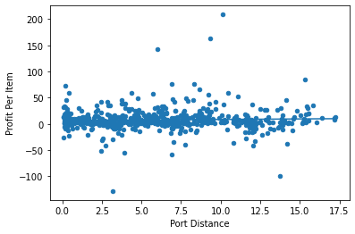

```python
m = np.polyfit(grouped_data2["Port Distance"], grouped_data2["Profit Per Item"], 1)
p = np.poly1d(m)
grouped_data2["trendline"] = p(grouped_data2.loc[:, "Port Distance"])

ax = grouped_data2.plot(x = "Port Distance", y = "Profit Per Item", kind = "scatter")
dfm2 = grouped_data2.set_index("Port Distance", inplace=False)
dfm2.trendline.sort_index(ascending=False).plot(ax=ax)
```

```python
slope, intercept, r_value, p_value, std_err = scipy.stats.linregress(grouped_data2['Port Distance'], grouped_data2['Profit Per Item'])
p_value
```

```
0.28374378416163254
```

```python
slope
```

```
0.20621553633367354
```

```python
slope, intercept, r_value, p_value, std_err = scipy.stats.linregress(grouped_data2['Port Distance'], grouped_data2['Sales'])
p_value
```

```
0.0010136492863376115
```

```python
slope
```

```
-246.3898496821685
```

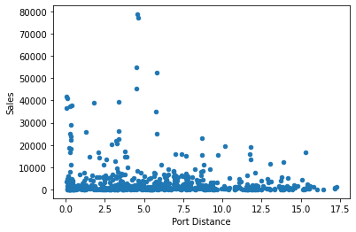

```python
ax = grouped_data2.plot(x = "Port Distance", y = "Sales", kind = "scatter")
dfm2 = grouped_data2.set_index("Port Distance", inplace=False)
```

**Insights**  
While we failed to reject our null hypothesis that there is no correlation between port distance and average profit per item, this can be due to a variety of factors. I initially thought that proximity to ports would reduce shipping costs, but this may not be the case if there are other factors influencing shipping costs. My set of ports is also incomplete, and a more complete set of ports that this superstore chain uses could make the analysis more accurate. Finally, it is doubtful that this dataset contains all transactions, so it could be that there is insufficient data to demonstrate the relationship.

I've added a toggle in the code to enable all ports in the US. Doing so reduces the p values of both profit per item and sales slightly, but it doesn't change enough to make the relationship between port distance and profit per item statistically significant.